# F1_variation_markdown2.0

Stephen Bovio

3/24/2021

## Aim

This project uses Admixem to simulate F1 hybrids under various genetic architectures and selection parameters and compares the coefficient of variation to that of the parental species. See: https://github.com/melop/admixem for instructions on installing and running Admixem. Next, a decision tree (https://www.guru99.com/r-decision-trees.html) is used to predict which genetic architectures and selection parameters are more likely to cause F1 hybrids to have a smaller coefficient of variaton than the parental species.

## Genertic architecture

**Genome Size:** 1 GB, 10 100Mb chromosomes  
**Recombination:** Recombination hotspots are evenly distributed along each chromosome  
**Number of genes contributing to trait of interest:** 10

### Parameters Simulated

I simulated all combinations of the following variables for a total of 1584 unique parameter combinations (ie 2 linkage states * 11 gene actions * 6 initial allele frequencies * 2 effect sizes * 6 selection parameters)

| linkage | gene action | initial allele frequency pop1 pop2 | effect size | selection |
| --- | --- | --- | --- | --- |
| unlinked | additive | 1.0 / 0.0 | 0.1 | no selection |
| linked | dominant | 0.9 / 0.1 | 0.9/0.01 | frequency-dependent (NS) |
|  | additive + dominant | 0.8 / 0.2 |  | negative frequency-dependent (NS) |
|  | epi1aa + additive | 0.7 / 0.3 |  | directional selection (NS) |
|  | epi1ad + additive | 0.6 / 0.4 |  | frequency-dependent (SS) |
|  | epi1da + additive | 0.5 / 0.5 |  | directional selection (SS) |
|  | epi1dd + additive |  |  |  |
|  | epi5aa |  |  |  |
|  | epi5ad |  |  |  |
|  | epi5da |  |  |  |
|  | epi5dd |  |  |  |

#### **Linkage**

I simulated two linkage states: unlinked and linked

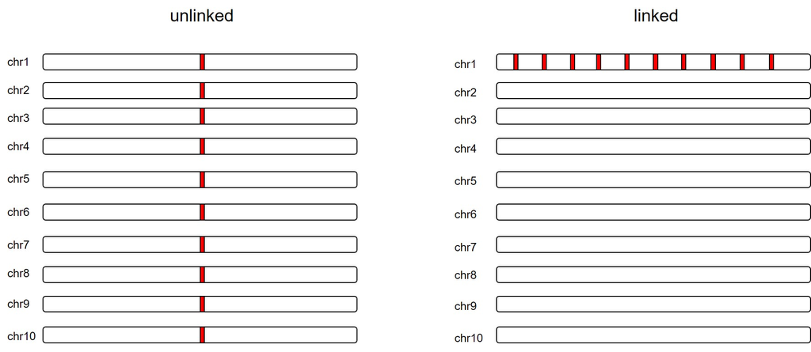

#### **Gene Action and Effect Sizes**

For each gene action, I simulated two different effect sizes. One where all ten loci had the same effect size (0.1), and another where one locus or epistatic pair contributed ~90% of the variation, while ~10% of the variation was distributed evenly among the remaining loci.

##### **Additive**

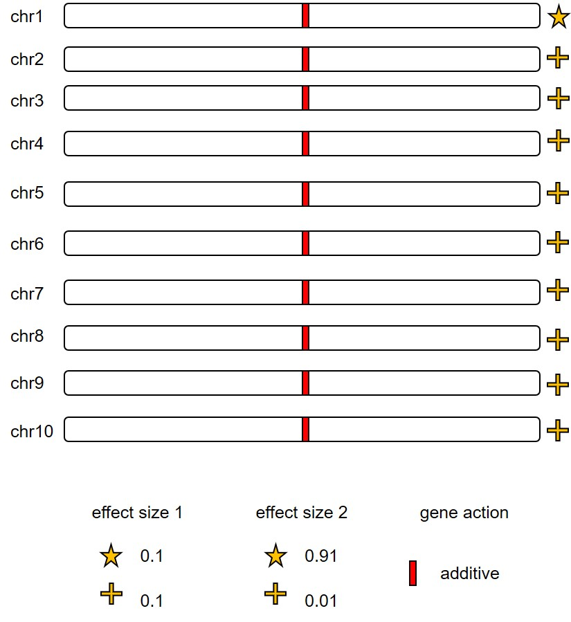

##### **Dominant**

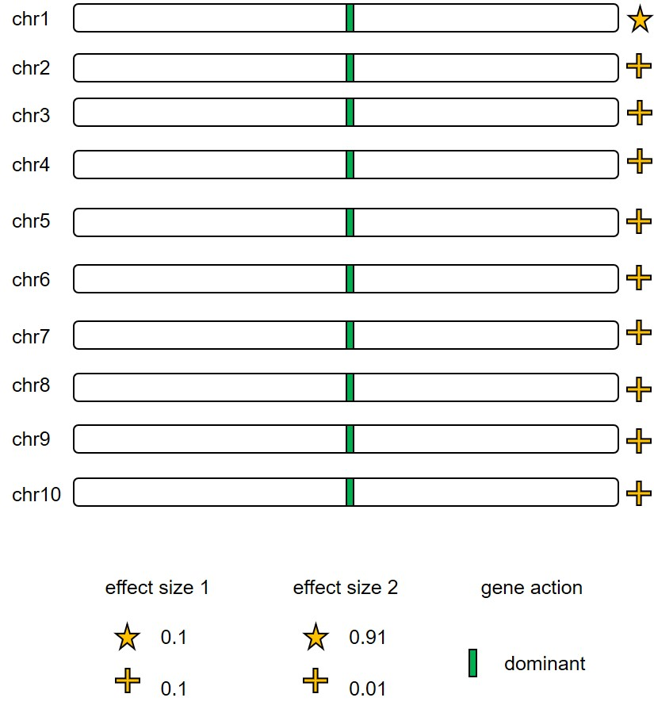

##### **Additive-Dominant**

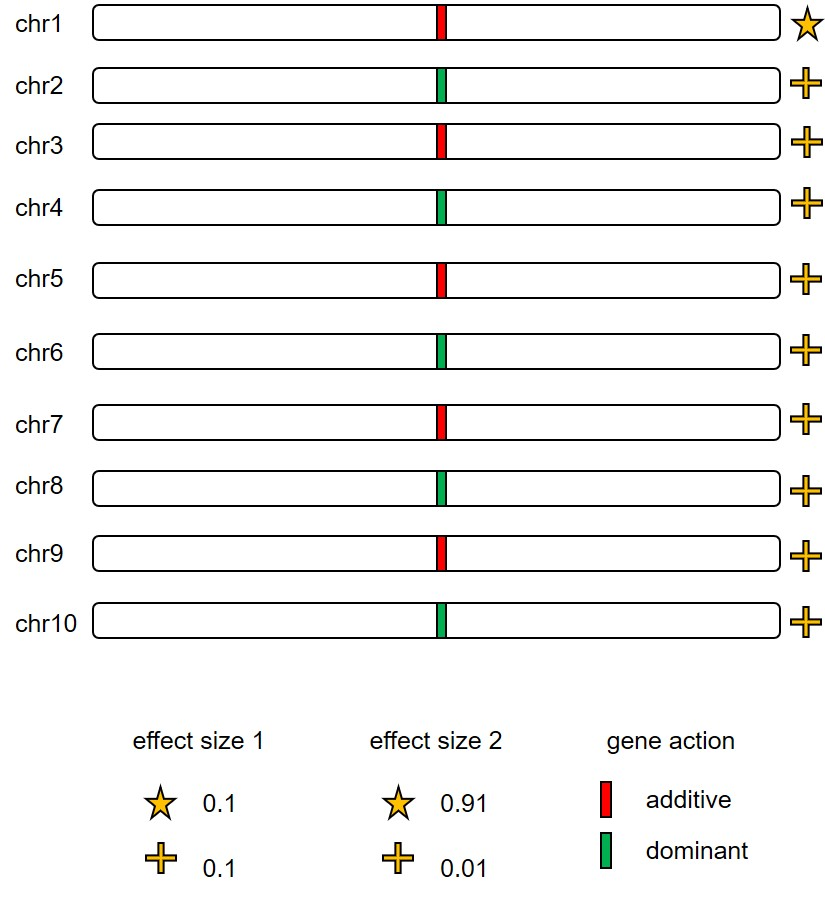

##### **Epistasis**

- For the epistatic gene action I simulated:
  - additive - additive
  - additive - dominant
  - dominant - additive
  - dominant - dominant

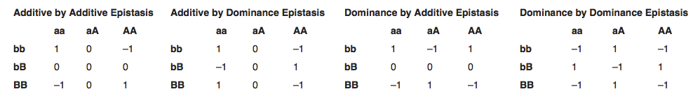

###### **1 pair**

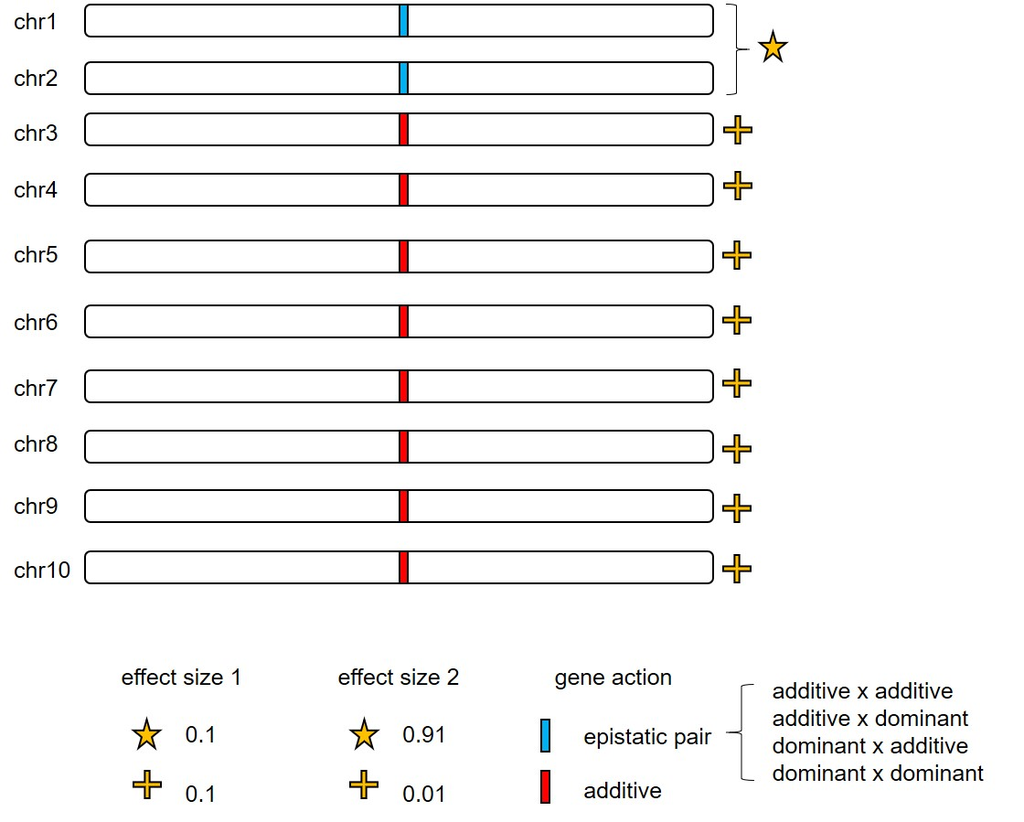

###### **5 pairs**

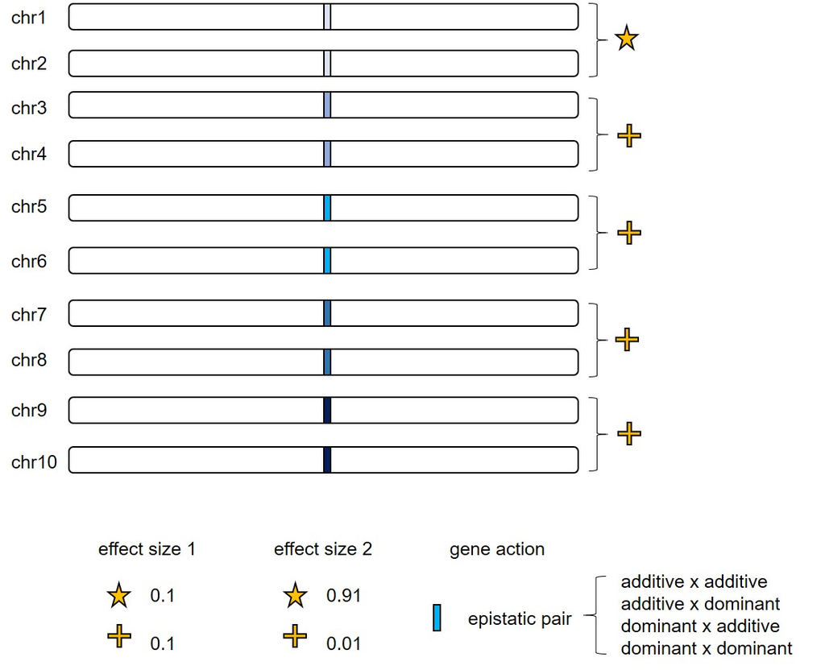

#### **Selection**

The formualas below will yield a value between 0 and 1 that determine the probability of mating (for SS) or surivival (for NS).

| selection | formula |
| --- | --- |
| no selection | none |
| frequency-dependent (NS) | exp( - pow( Couter_Trait – PopCourter_Avg_Trait , 2)/(2 * pow(PopCourter_Std_Trait/2,2))) |
| negative frequency-dependent (NS) | 1 - exp( - pow( Couter_Trait – PopCourter_Avg_Trait , 2)/(2 * pow(PopCouter_Std_Trait/2,2))) |
| directional selection (NS) | exp( - pow( Courter_Trait - (PopCourter_Avg_Trait-PopCourter_Std_Trait) , 2)/(2 * pow(PopCourter_Std_Trait/2,2))) |
| frequency-dependent (SS) | exp( - pow( Couter_Trait – PopCourter_Avg_Trait , 2)/(2 * pow(PopCourter_Std_Trait/2,2))) |
| directional selection (SS) | exp( - pow( Courter_Trait - (PopCourter_Avg_Trait-PopCourter_Std_Trait) , 2)/(2 * pow(PopCourter_Std_Trait/2,2))) |

## Admixem

### Bash Script

The following bash script depends on several R scripts and admixem configuration files which can be found below as well. See: https://github.com/melop/admixem for instructions on configuring these files.

**CLICK HERE TO SEE BASH SCRIPT**

```
## #!/bin/sh
## #SBATCH -J linked_additive_esize0.1_noss_nons
## #SBATCH --time=06:00:00
## #SBATCH -n1
## #SBATCH --mem=32000
## #SBATCH --mail-user=rbovio@tamu.edu
## #SBATCH -o linked_additive_esize0.1_noss_nons-%j.out
## #SBATCH -e linked_additive_esize0.1_noss_nons-%j.err
##
##
##
## #######################
## #EDIT THESE PARAMETERS#
## #######################
## parameters=linked_additive_esize0.1_noss_nons;
## genes_file=genes_$parameters.txt
## admixem_file=admixsimul_$parameters.txt
##
## #make and empty directory so admixem starts making directories for each replicate that have the prefix number
## mkdir F1_$parameters
##
## export LANG=en_US.UTF-8
## #load R module
## module load R_tamu/3.6.2-intel-2019b-recommended-mt
##
## #iterate through initial allele frequencies
## #change k for the number of initial allele frequencies you want to simulate
## for((k=1; k<=6; k++)){
##  #value to increment intital allele frequencies by
##  increment_value=0.10
##  Rscript increment_genes.R $genes_file $increment_value
##
##  #Run job_file.slrm 1000 times
##  echo "starting at date on hostname"
##  #change i for number of replicates you want to simulate
##  for ((i=1;i<=100;i++))
##  do
##  echo "replicate $i"
##
##  #perl -i.bak -lpe 'BEGIN { sub inc { my ($num) = @_; ++$num } } s/(RandomSeed=)(\d+)/$1 . (inc($2))/eg' $admixem_file
```

[output cut: 41 more lines]

```
## }
##
## #Rscript to plot prop_overlap x initial allele frequencies
## Rscript prop_overlap.R $parameters
##
## #combine dataframe output for each initial allele freq into a single spreadsheet
## head -1 df_$parameters.1.csv > df_$parameters\_all.csv; tail -n +2 -q df_$parameters.* >> df_$parameters\_all.csv
##
## mkdir output_$parameters
## mv variation_mean_and_cv_density_$parameters* output_$parameters
## mv prop_overlap_mean_$parameters* output_$parameters
## mv proportion_overlap_mean_$parameters* output_$parameters
## mv num_failed_sims_$parameters* output_$parameters
## mv df_$parameters* output_$parameters
## mv linked_additive_esize0.1_noss_nons-* output_$parameters
```

### Admixem configuration files

**CLICK HERE TO SEE CONFIGURATION FILES**

**admixsimul_linked_additive_esize0.1_noss_nons.txt**

```
## RandomSeed   =   1.1
## MarkerFile   =   markers.txt #Marker File Containing marker info.
## MarkerProbFile   =   recombination_hotspots.txt  #Recombination probabilities
## UseUniformRec    =   no  # ignore predefined breakpoints above, use uniform.
## IgnoreMarkerFreq     =   yes #Ignore marker frequencies specified in file and use 1 for pop1, 0 for pop2, this equivalent to fixed differences
## DumpNatSelProb  = Off
## GeneFile             =   genes_linked_additive_esize0.1_noss_nons.txt
## PhenotypeFile    = phenotypes_linked_additive_esize0.1_noss_nons.txt   #Phenotype File
## OutputFolder             = /scratch/user/rbovio/admixem3.0/admixem-master3.0/bin/F1_linked_additive_esize0.1_noss_nons
## NaturalSelection =  naturalsel_linked_additive_esize0.1_noss_nons.txt  #definition of natural selection
## SexualSelection  =   sexualsel_linked_additive_esize0.1_noss_nons.txt
##     #only one character is allowed
## #population names:
## pop2_name =      birchmanni  #0%
## pop2_ancestry_label =    b
## hybrid_name = hyb1  #5
## pop1_name = malinche  #100%
## pop1_ancestry_label =     m
##
## #Pop sizes
## pop1_init_size    = 50
## pop1_size_limit   = 50     #mal Size limit
## pop2_init_size    = 50
## pop2_size_limit   = 50    #birch Size Limit
## hybrid_size_limit = 50
##
##
## pop1_male_ratio = 1
## pop2_male_ratio = 0
## migration_only_first_gen = yes
##
## #migration first generation:
## #birch to hybrid
## gen0_pop2_to_hybrid = 25
##
## #mal to hybrid
## gen0_pop1_to_hybrid = 25
##
## #migration  interpopulations each gen:
## #simmetrical m=0.1 100 from 1000, only to adjacent populations, no migration to parentals
## #Pop 2
## pop2_to_pop1 = 0
## pop2_to_hybrid= 0
##
## #hybrid
## hybrid_to_pop2 = 0
## hybrid_to_pop1 = 0
##
## #pop1
## pop1_to_pop2 = 0
## pop1_to_hybrid = 0
##
## generations = 1
## avg_female_gamete    =   10
## std_female_gamete    =   3.16
## kids_per_female_func = Poisson
## samplefreq     = 1 #sample every generation
## MarkerOutput   = Off #On or Off
## SampleMate =  50 #random mating
## NumThreads  = 1
## samplegens      = samplegens.txt
```

**markers.txt**

```
## HaploidChromosomeNum = 11
## RandomSeed = 0.1
## Pop1AvgAlleleFreq = 1
## Pop1AvgAlleleFreqStdev = 0
## Pop2AvgAlleleFreq = 1
## Pop2AvgAlleleFreqStdev = 0
## :chr 1   len = 1e+08 centromere = 1e+08
##
## Num  Position Percentage Position Abs.   Freq. Pop 1 Freq. Pop 2
## 1    0.10    1.00E+07    1   0
## 2    0.20    2.00E+07    1   0
## 3    0.30    3.00E+07    1   0
## 4    0.40    4.00E+07    1   0
## 5    0.50    5.00E+07    1   0
## 6    0.60    6.00E+07    1   0
```

[output cut: 134 more lines]

**genes_linked_additive_esize0.1_noss_nons.txt**

```
## name Chromosome  position    Dominant.Allele Dominant.Allele.Value   Recessive.Allele    Recessive.Allele.Value  Mode    Dominant.Freq.Pop1  Dominant.Freq.Pop2
## chr1_5000000 1   5000000 A   1   a   2   Additive    1   0
## chr1_10000000    1   10000000    B   0.5 b   0   Additive    1.10    -0.10
## chr1_20000000    1   20000000    C   0.5 c   0   Additive    1.10    -0.10
## chr1_30000000    1   30000000    D   0.5 d   0   Additive    1.10    -0.10
## chr1_40000000    1   40000000    E   0.5 e   0   Additive    1.10    -0.10
## chr1_50000000    1   50000000    F   0.5 f   0   Additive    1.10    -0.10
## chr1_60000000    1   60000000    G   0.5 g   0   Additive    1.10    -0.10
## chr1_70000000    1   70000000    H   0.5 h   0   Additive    1.10    -0.10
## chr1_80000000    1   80000000    I   0.5 i   0   Additive    1.10    -0.10
## chr1_90000000    1   90000000    J   0.5 j   0   Additive    1.10    -0.10
## chr1_100000000   1   100000000   K   0.5 k   0   Additive    1.10    -0.10
## chr11_500000 11  500000  S   1   s   0   Hemizygous  0.5 0.5
```

**phenotypes_linked_additive_esize0.1_noss_nons.txt**

```
## Phenotypes   Formula
## Trait0   chr1_10000000
## Trait1   chr1_10000000*0.1+chr1_20000000*0.1+chr1_30000000*0.1+chr1_40000000*0.1+chr1_50000000*0.1+chr1_60000000*0.1+chr1_70000000*0.1+chr1_80000000*0.1+chr1_90000000*0.1+chr1_100000000*0.1
##
## Sex  chr11_500000
```

**naturalsel_linked_additive_esize0.1_noss_nons.txt**

```
## Population   Gen Selection
## malinche -1  1
## birchmanni   -1  1
## hyb1 -1  1
```

**sexualsel_linked_additive_esize0.1_noss_nons.txt**

```
## Population   Gen Selection
## malinche -1  1
## birchmanni   -1  1
## hyb1 -1  1
```

**samplegens.txt**

```
## 1    1
```

### Rscripts

Below are the Rscripts that are called in the bash script.

**CLICK HERE TO SEE RSCRIPTS**

**increment_genes.R**

```
## arrArgs <- commandArgs(trailingOnly = TRUE)
## genes_file<-as.character(arrArgs[1])
## increment_value<-as.numeric(arrArgs[2])
##
## my_func = function(increment_value){
## genes = read.delim(paste(genes_file), sep = "\t")
## genes$Dominant.Freq.Pop1[2:11] = genes$Dominant.Freq.Pop1[2:11] - increment_value
## genes$Dominant.Freq.Pop2[2:11] = genes$Dominant.Freq.Pop2[2:11] + increment_value
## write.table(genes, paste(genes_file), sep = '\t', quote = FALSE, row.names = FALSE)
## }
##
## my_func(increment_value)
```

**phenotype_parser.R**

```
#load packages
library(ggplot2, lib.loc = "/scratch/user/rbovio/R_LIBS_USER/3.6.2-intel-2019b-recommended-mt")
library(reshape2, lib.loc = "/scratch/user/rbovio/R_LIBS_USER/3.6.2-intel-2019b-recommended-mt")
library(DescTools, lib.loc = "/scratch/user/rbovio/R_LIBS_USER/3.6.2-intel-2019b-recommended-mt")
library(ggpubr, lib.loc = "/scratch/user/rbovio/R_LIBS_USER/3.6.2-intel-2019b-recommended-mt")
library(cowplot, lib.loc = "/scratch/user/rbovio/R_LIBS_USER/3.6.2-intel-2019b-recommended-mt")

#store command line arguements as variables
arrArgs <- commandArgs(trailingOnly = TRUE)
parameters<-as.character(arrArgs[1])
p1_af<-as.character(arrArgs[2])
p2_af<-as.character(arrArgs[3])

parameters_list = strsplit(parameters,"_")
linkage<- parameters_list[[1]][1]
gene_action = parameters_list[[1]][2]
esize<- parameters_list[[1]][3]
ss<- parameters_list[[1]][4]
ns<- parameters_list[[1]][5]


#create a dataframe to store the mean/sd/cv phenotype for each iteration/replicate
df = data.frame(NULL)

#create parameter counters
proportion_overlap_mean_p1 = 0
proportion_overlap_mean_p2 = 0
novelty = 0 #95% CI doesn't overlap with p1 or p2
num_failed_sims = 0

#loop through each directory (ie iteration)
for(i in 1:100){
  setwd(paste0("/scratch/user/rbovio/admixem3.0/admixem-master3.0/bin/F1_",parameters,"_",i))
  f = 'hybrids00'
  if(file.exists(f)==FALSE){
    num_failed_sims = num_failed_sims + 1
    next
  }
  #get parental and hybrid phenotype values
  p1m_data = read.delim(file = "parents00", header = TRUE)
  p2f_data = read.delim(file = "parents01", header = TRUE)
  hm_data = read.delim(file = "hybrids00", header = TRUE)
  hf_data = read.delim(file = "hybrids01", header = TRUE)


  #append to the dataframe
  df = rbind(df, c(i,
                   mean(p1m_data$Trait1),
                   mean(p2f_data$Trait1),
                   mean(c(hm_data$Trait1,hf_data$Trait1)), # EDIT HERE mean(ns$x)
                   sd(p1m_data$Trait1),
                   sd(p2f_data$Trait1),
                   sd(c(hm_data$Trait1,hf_data$Trait1)),
                   sd(p1m_data$Trait1)/mean(p1m_data$Trait1),
                   sd(p2f_data$Trait1)/mean(p2f_data$Trait1),
                   sd(c(hm_data$Trait1,hf_data$Trait1))/mean(c(hm_data$Trait1,hf_data$Trait1))))

  # Summary statistics for each replicate in order to determine proportion of replicates that show novel phenotypes
  p1_mean = mean(p1m_data$Trait1)
  p1_sd = sd(p1m_data$Trait1)
  p1_cv = p1_sd/p1_mean
  p1_n = nrow(p1m_data)
  p1_error <- qnorm(0.975)*p1_sd/sqrt(p1_n)
  p1_left  <- p1_mean - p1_error
  p1_right <- p1_mean + p1_error
  p1_sum_stat <- cbind(p1_left, p1_mean, p1_right)

  p2_mean = mean(p2f_data$Trait1)
  p2_sd = sd(p2f_data$Trait1)
  p2_cv = p2_sd/p2_mean
  p2_n = nrow(p2f_data)
  p2_error <- qnorm(0.975)*p2_sd/sqrt(p2_n)
  p2_left  <- p2_mean - p2_error
  p2_right <- p2_mean + p2_error
  p2_sum_stat <- cbind(p2_left, p2_mean, p2_right)

  h_mean = mean(c(hm_data$Trait1,hf_data$Trait1))
  h_sd = sd(c(hm_data$Trait1,hf_data$Trait1))
  h_cv = h_sd/h_mean
  h_n = nrow(hm_data)+nrow(hf_data)
  h_error <- qnorm(0.975)*h_sd/sqrt(h_n)
  h_left  <- h_mean - h_error
  h_right <- h_mean + h_error
  h_sum_stat <- cbind(h_left, h_mean, h_right)

  #check range overlap
  p1_range = c(p1_sum_stat[1,1],p1_sum_stat[1,3])
  p2_range = c(p2_sum_stat[1,1],p2_sum_stat[1,3])
  h_range = c(h_sum_stat[1,1],h_sum_stat[1,3])
  if(p1_range %overlaps% h_range == TRUE){
    proportion_overlap_mean_p1 = proportion_overlap_mean_p1 + 1
    # print(p1_range)
    # print(h_range)
  }
  if(p2_range %overlaps% h_range == TRUE){
    proportion_overlap_mean_p2 = proportion_overlap_mean_p2 + 1
    # print(p2_range)
    # print(h_range)
  }
  if(p1_range %overlaps% h_range == FALSE & p2_range %overlaps% h_range == FALSE){
    novelty = novelty + 1
  }
  colnames(df) = c("replicate",
                   "p1_mean","p2_mean","h_mean",
                   "p1_sd","p2_sd","h_sd",
                   "p1_cv","p2_cv","h_cv")

  setwd("/scratch/user/rbovio/admixem3.0/admixem-master3.0/bin")
}
#add all parameters to df dataframe for writing
df$linkage = linkage
df$gene_action =  gene_action
df$p1_af = p1_af
df$p2_af = p2_af
df$esize = esize
df$ss = ss
df$ns = ns
write.csv(df, paste0("df_",parameters,".csv"), quote = FALSE, row.names = FALSE)

#remove unneccesary columns for remaining analysis
df = df[,2:10]

p_o_mean = matrix(ncol = 3, nrow = 1)
p_o_mean[1,1] = proportion_overlap_mean_p1
p_o_mean[1,2] = proportion_overlap_mean_p2
p_o_mean[1,3] = novelty
write.table(p_o_mean, paste0("prop_overlap_mean_",parameters,".txt"), quote = FALSE, row.names = FALSE)
write.table(num_failed_sims, paste0("num_failed_sims_",parameters,".txt"), quote = FALSE, row.names = FALSE)

df_mean = df[,1:3]
colnames(df_mean) = c("p1","p2","h")
df_mean = melt(df_mean, measure.vars = c(1,2,3))
df_mean$variable <- factor(df_mean$variable, levels = c("p1", "h", "p2"))

df_sd = df[,4:6]
colnames(df_sd) = c("p1","p2","h")
df_sd = melt(df_sd, measure.vars = c(1,2,3))
df_sd$variable <- factor(df_sd$variable, levels = c("p1", "h", "p2"))

df_cv = df[,7:9]
colnames(df_cv) = c("p1","p2","h")
df_cv = melt(df_cv, measure.vars = c(1,2,3))
df_cv$variable <- factor(df_cv$variable, levels = c("p1", "h", "p2"))
df_cv[is.na(df_cv)] <- 0

#summary statistics over all replicates to get 95% CI
mean_vec <- colMeans(df)
sd_vec   <- apply(df, 2, sd)
n        <- nrow(df) #number of replicates

error <- qnorm(0.975)*sd_vec/sqrt(n)
left  <- mean_vec - error
right <- mean_vec + error

sum_stat <- cbind(left, mean_vec, right)

#mean
sum_stat_mean = sum_stat[1:3,]

sum_stat_mean = as.data.frame(sum_stat_mean)
sum_stat_mean$y = 0
sum_stat_mean$variable = factor(c("p1","p2","h"), levels = c("p1","p2","h"), ordered = TRUE)
sum_stat_mean$variable = factor(sum_stat_mean$variable, levels = c("p1","h","p2"))

l <- density(df_mean$value)
p <- ggplot(data =df_mean, aes(x=value, group = variable, fill = variable)) +
  geom_density(alpha = 0.6, show.legend = FALSE) +
  scale_fill_manual(values=c("steelblue1", "springgreen1","tomato1")) +
  xlim(c(0,1)) +
  xlab("mean") +
  labs(fill = "population") +
  geom_point(inherit.aes = FALSE, data = sum_stat_mean,
             aes(x= mean_vec, y = y, color = variable, size = 1.5),show.legend = FALSE)+
  geom_errorbarh(inherit.aes = FALSE, data = sum_stat_mean,
                 aes(xmin = left, xmax = right, y = y, color = variable),
                 height = 0.1, show.legend = FALSE, size = 1.5) +
  scale_color_manual(values=c( "steelblue4","springgreen4", "tomato4")) +
  theme_bw()

# #sd
sum_stat_sd = sum_stat[4:6,]

sum_stat_sd = as.data.frame(sum_stat_sd)
sum_stat_sd$y = 0
sum_stat_sd$variable = factor(c("p1","p2","h"), levels = c("p1","p2","h"), ordered = TRUE)
sum_stat_sd$variable = factor(sum_stat_sd$variable, levels = c("p1","h","p2"))

l <- density(df_sd$value)
pp <- ggplot(data =df_sd, aes(x=value, group = variable, fill = variable)) +
  geom_density(alpha = 0.6) +
  scale_fill_manual(values=c("steelblue1", "springgreen1","tomato1")) +
  xlim(range(l$x)) +
  xlab("standard deviation") +
  labs(fill = "population") +
  geom_point(inherit.aes = FALSE, data = sum_stat_sd,
             aes(x= mean_vec, y = y, color = variable, size = 1.5),show.legend = FALSE)+
  geom_errorbarh(inherit.aes = FALSE, data = sum_stat_sd,
                 aes(xmin = left, xmax = right, y = y, color = variable),
                 height = 0.1, show.legend = FALSE, size = 1.5) +
  scale_color_manual(values=c( "steelblue4", "springgreen4","tomato4")) +
  theme_bw()

#cv
sum_stat_cv = sum_stat[7:9,]

sum_stat_cv = as.data.frame(sum_stat_cv)
sum_stat_cv$y = 0
sum_stat_cv$variable = factor(c("p1","p2","h"), levels = c("p1","p2","h"), ordered = TRUE)
sum_stat_cv$variable = factor(sum_stat_cv$variable, levels = c("p1","h","p2"))

l <- density(df_cv$value)
ppp <- ggplot(data =df_cv, aes(x=value, group = variable, fill = variable)) +
  geom_density(alpha = 0.6, show.legend = FALSE) +
  scale_fill_manual(values=c("steelblue1", "springgreen1","tomato1")) +
  xlim(range(l$x)) +
  xlab("coefficient of variation") +
  labs(fill = "population") +
  geom_point(inherit.aes = FALSE, data = sum_stat_cv,
             aes(x= mean_vec, y = y, color = variable, size = 1.5),show.legend = FALSE)+
  geom_errorbarh(inherit.aes = FALSE, data = sum_stat_cv,
                 aes(xmin = left, xmax = right, y = y, color = variable),
                 height = 0.1, show.legend = FALSE, size = 1.5) +
  scale_color_manual(values=c( "steelblue4", "springgreen4","tomato4")) +
  theme_bw()

#PLOT
legend <- cowplot::get_legend(pp)
# text <- paste0("p1 = ",p1_af,", p2 =",p2_af)
# # Create a text grob
# tgrob <- text_grob(text,size = 20)
# # Draw the text
# plot_0 <- as_ggplot(tgrob) + theme(plot.margin = margin(0,3,0,0, "cm"))
# save plot as jpeg
options(bitmapType='cairo')
jpeg(file=paste0("variation_mean_and_cv_density_",parameters,"_p1-",p1_af,"_p2-",p2_af,".jpeg"), width = 1000, height = 600)
# ggarrange(plot_0, NULL, NULL,p,ppp,legend,nrow=2,ncol=3, widths = c(3,3,1), heights = c(1,10))
ggarrange(p,ppp,legend,nrow=1,ncol=3, widths = c(3,3,1))
dev.off()
```

**prop_overlap.R**

```
## library(ggplot2)
## library(reshape2)
##
## arrArgs <- commandArgs(trailingOnly = TRUE)
## parameters<-as.character(arrArgs[1])
##
## path = getwd()
## data<-data.frame(NULL)
## file.names <- dir(path, pattern =paste0("prop_overlap_mean_",parameters))
## for(i in 1:length(file.names)){
##   file <- read.table(file.names[i],header=TRUE, sep=" ")
##   data <- rbind(data, file)
## }
##
## data$initial_af_p1 = seq(1,0.5,-0.1)
## data$initial_af_p2 = seq(0,0.5,0.1)
## colnames(data) = c('p1-hybrid overlap', "p2-hybrid overlap",'novelty', 'initial_af_p1', "initial_af_p2")
## data = melt(data, id.vars = c('initial_af_p1', "initial_af_p2"))
## data$value = data$value #if you do 1000 replicates, divide by 10 to make it a proportion between 0-100.
##
## p = ggplot(data, aes(x=interaction(initial_af_p1, initial_af_p2), y = value, group = variable, color = variable)) +
##     theme_bw() +
##     geom_point() +
##     geom_line() +
##     ggtitle("proportion of replicates where the mean phenotype between\nhybrid and parental populations overlap") +
##     annotate(geom = "text", x = seq(1,6), y = -10, label = unique(data$initial_af_p1), size = 3) +
##     annotate(geom = "text", x = seq(1,6), y = -15, label = unique(data$initial_af_p2), size = 3) +
##     annotate(geom = "text", x = 7, y = -10, label = "p1 initial allele frequency", size = 3, hjust = 0) +
##     annotate(geom = "text", x = 7, y = -15, label = "p2 initial allele frequency", size = 3, hjust = 0) +
##     coord_cartesian(ylim = c(-5, 105), expand = FALSE, clip = "off") +
##
##     theme(plot.margin = unit(c(1, 1, 4, 1), "lines"),
##           plot.title = element_text(hjust = 0.5),
##           axis.title.x = element_blank(),
##           axis.text.x = element_blank(),
##           panel.grid.major.x = element_blank(),
##           panel.grid.minor.x = element_blank())
##
##
##
## options(bitmapType='cairo')
## jpeg(file=paste0("proportion_overlap_mean_",parameters,".jpeg"))
## p
## dev.off()
```

## Results

Here I plot the average mean and coefficient of variation between hybrid and parental popluations. I have plots like these for each parameter combination, but for sake of space/simplicity I’ve only shown this one set of conditions.

### Initial allele frequency: P1=1.0 / P2=0.0

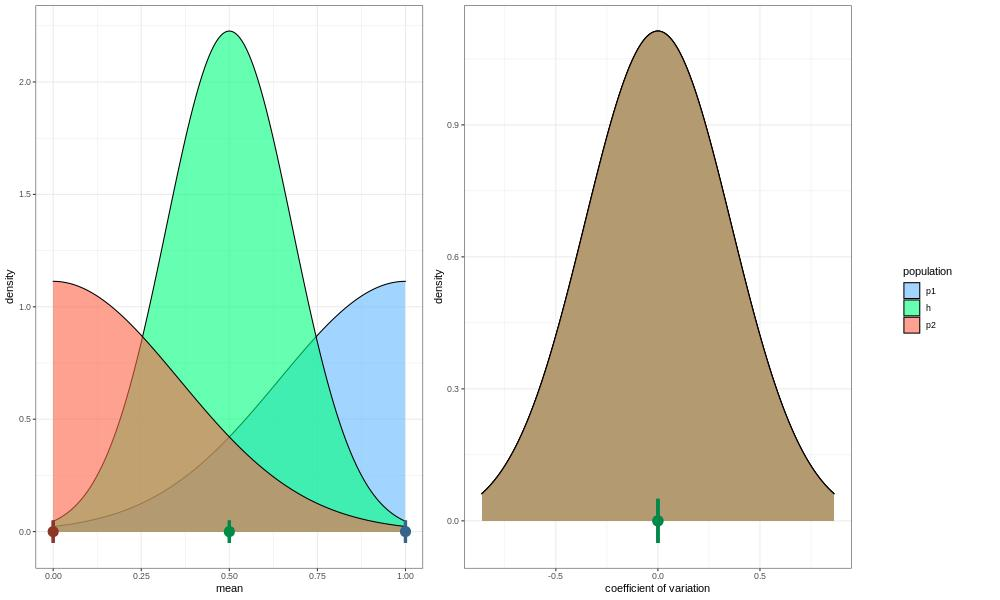

### Initial allele frequency: P1=0.9 / P2=0.1

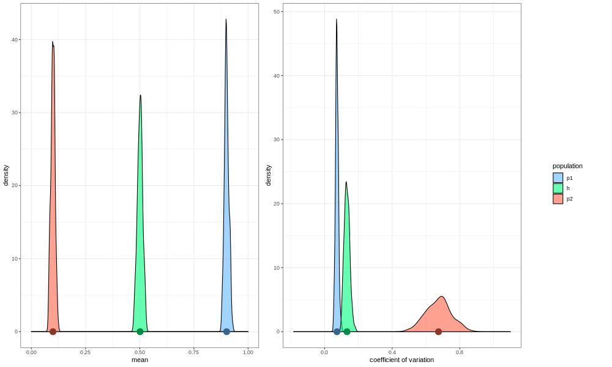

### Initial allele frequency: P1=0.8 / P2=0.2

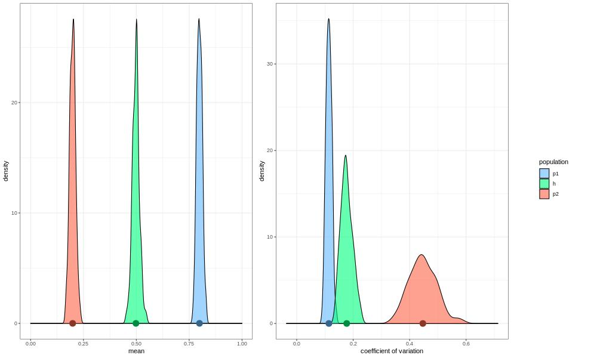

### Initial allele frequency: P1=0.7 / P2=0.3

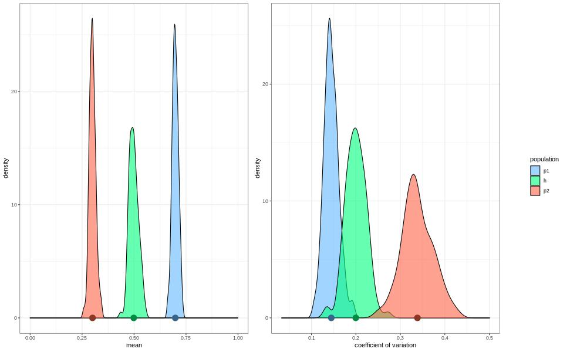

### Initial allele frequency: P1=0.6 / P2=0.4

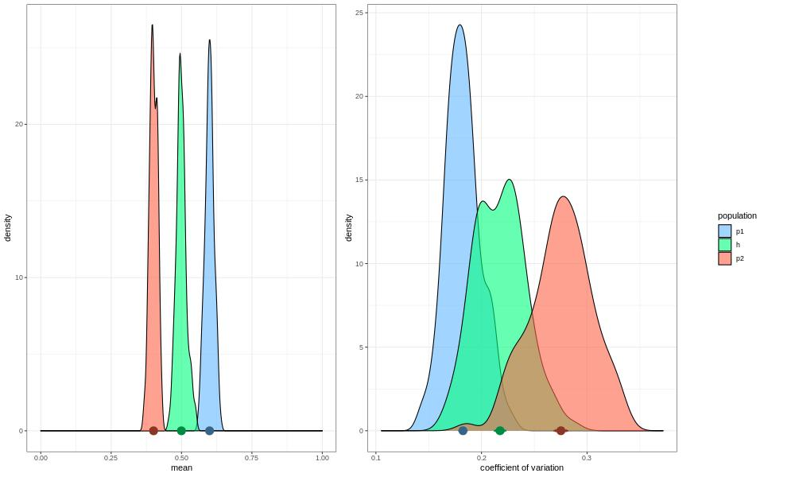

### Initial allele frequency: P1=0.5 / P2=0.5

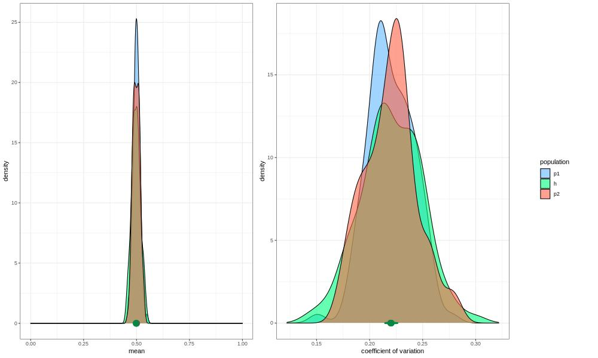

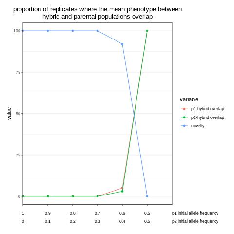

### Decision Tree

When we do this for every parameter combination, we can use a decision tree to create a model that predicts the value of a target variable (ie cvstatus) based on several input variables (ie linkage, gene action, allele frequency, effect sizes, and selection).

- Each node shows
  - the predicted class (larger or smaller),
  - the predicted probability of having a smaller coefficient of variation,
  - the percentage of observations in the node.

Below is the Rscript used to construct the decision tree.

**CLICK HERE TO SEE RSCRIPT**

**decision_trees.R**

```
## #Classification tree instructions - from https://www.guru99.com/r-decision-trees.html
##
## #LOAD PACKAGES
## library(rpart)
## library(rpart.plot)
##
## #IMPORT DATA
## onlypopcomparisons = read.csv("all_parameters.csv")
## onlypopcomparisons2 = onlypopcomparisons
##
## #######RE-EDIT below so that there is a new variable for simulations that didn't produce hybrids or only produced 1 hybrid
##
## #CLEAN DATA
## #remove simulations where no hybrids survived
## onlypopcomparisons2 = onlypopcomparisons2[complete.cases(onlypopcomparisons2[ , 4]),]
## #convert p2_cv, h_sd, and h_cv NA's to zero
## for(i in 1:nrow(onlypopcomparisons2)){
##   if(onlypopcomparisons2$p2_mean[i] == 0){
##     onlypopcomparisons2$p2_cv[i] = 0
##   }
##   if(is.na(onlypopcomparisons2$h_sd[i]) == T | is.na(onlypopcomparisons2$h_cv[i]) == T){
##     onlypopcomparisons2$h_sd[i] = 0
##     onlypopcomparisons2$h_cv[i] = 0
##   }
## }
##
## #DETERMINE CV STATUS
## onlypopcomparisons2$cvstatus = NA
## for(i in 1:nrow(onlypopcomparisons2)){
##   if(onlypopcomparisons2$h_cv[i] < onlypopcomparisons2$p1_cv[i] & onlypopcomparisons2$h_cv[i] < onlypopcomparisons2$p2_cv[i]){
##     onlypopcomparisons2$cvstatus[i] = 'smaller'
##   }
##   else{
##     onlypopcomparisons2$cvstatus[i] = 'larger'
##   }
## }
##
## #Notice the data is not shuffled. This is a big issue!
## #It means the algorithm will never see all the features. This mistake will lead to poor prediction.
## #shuffle the data around
```

[output cut: 26 more lines]

```
## #Do sanity checks. Does the proportion of CV smaller you calculated earlier match
## #the proportion in the top node? If they match - that is good. If they don't,
## #something is messed up.
##
## #MAKE PREDICTIONS AND MEASURE PERFORMANCE
## predict_unseen <- predict(fit, data_test, type = "class")
## #Test hybrids that had smaller CV and larger CV than both parents
## table_mat <- table(data_test$cvstatus, predict_unseen)
## table_mat
## #Sanity check - the values in this table should add to the number of observations
## #in data_test
##
## #Measure performance with a confusion matrix
## accuracy_Test <- sum(diag(table_mat))/sum(table_mat)
## print(paste('Accuracy for test', accuracy_Test))
```

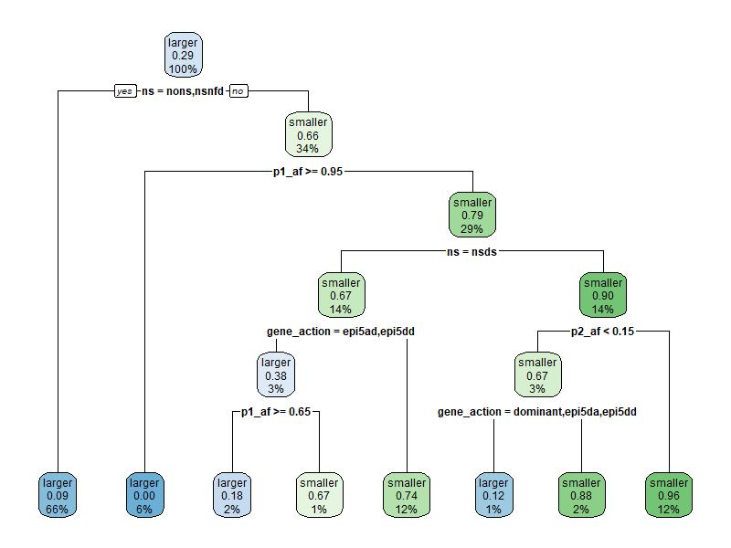

**Accuracy for test:** 0.895580110497238